# Introduction to Programming in R

September 2020

## Outline

- Functions
- Programming Basics in R
- Loops
- Apply functions
- purrr package

## Functions

A **function** is a set of statements organized together to perform a specific task. each function has four components:

- Function Name: Functions are stored as an object with this name.
- Argument: When a function is invoked, you pass a value to the argument.
- Function Body: The function body contains a collection of statements that defines what the function does.
- Return Value: The return value of a function is the last expression in the function body to be evaluated.

```r
function_name <- function(arg_1, arg_2, ...) {
   Function body
}
```

## Example

A basic function that shows basic statistics

```r
summary <- function(x){
  a1 <- mean(x) ; a2 <- median(x); a3 <- var(x); a4 <- sd(x)
  output <- data.frame(Mean = a1, Median = a2, Var = a3, SD = a4)
  return(output)
}

x <- 1:10
summary(x)
```

```
##   Mean Median      Var      SD
## 1  5.5    5.5 9.166667 3.02765
```

## Pipes (Magrittr)

Pipes are a powerful tool for clearly expressing a sequence of multiple operations. **magrittr** package ofefrs a couple of pipe operators that can be versatile in programming.

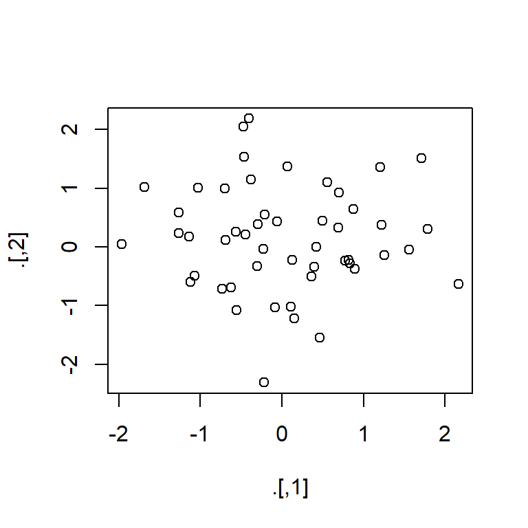

```r
library(tidyverse)
set.seed(123)
rnorm(100) %>%
  matrix(ncol = 2) %>%
  plot()
```

## Pipes

Look at the difference between `%>%` and `%T>%`. First, try the code below with the pipe operator. Then, try with `%T>%`.

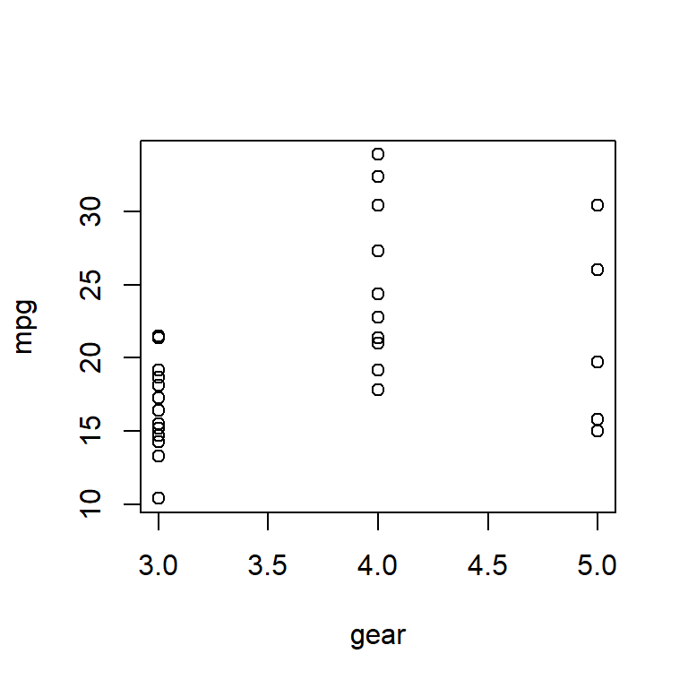

```
##     gear      mpg
##  3.68750 20.09062
```

```r
library(tidyverse)
data(mtcars)
mtcars %>%
  select(gear,mpg) %T>%
  plot() %>%
  apply(2,mean)
```

## Infix operators

Infix operators in R are unique functions and methods that facilitate basic data expressions or transformations.

- :: Extract function from a package namespace
- $ Extract list subset
- @ Extract Slot selection
- [ and [[ Extract Subscripting
- %in% Comparison Value Matching
- xor Logical Exclusive
- && Logical and (control)

For a list of infix operators check (https://bit.ly/32ewCNP)

## If-else

```r
if(cond) cons.expr else alt.expr
ifelse(test, yes, no)
```

```r
library(dplyr)
library(knitr)
data(mtcars)
mtcars%>%
  mutate(Efficiency = ifelse(mpg <= 10 ,"F",ifelse(
    mpg >11 & mpg <= 15,"E",ifelse(
      mpg > 15 & mpg <=20,"D",ifelse(
        mpg > 20 & mpg <=25,"C",ifelse(
          mpg > 25 & mpg <=30,"B","A")))))) %>%
  select(mpg, Efficiency) %>% head() %>% kable()
```

| mpg | Efficiency |
| --- | --- |
| 21.0 | C |
| 21.0 | C |
| 22.8 | C |
| 21.4 | C |
| 18.7 | D |
| 18.1 | D |

## For

```r
for(var in seq) expr
```

Replicate the scale function `scale()`:

```r
row <- nrow(mtcars)
col <- ncol(mtcars)
for.mtcars_normalized <- data.frame(1:row)
for (i in 1:col) {
  avr <- mean(mtcars[,i])
  dev <- sd(mtcars[,i])
  for (j in 1:row) {
    for.mtcars_normalized[j,i] <- (mtcars[j,i] - avr) / dev
    }
  }
names(for.mtcars_normalized) <- names(mtcars)
head(for.mtcars_normalized, n=5L)[1:5]
```

```
##          mpg        cyl       disp         hp       drat
## 1  0.1508848 -0.1049878 -0.5706198 -0.5350928  0.5675137
## 2  0.1508848 -0.1049878 -0.5706198 -0.5350928  0.5675137
## 3  0.4495434 -1.2248578 -0.9901821 -0.7830405  0.4739996
## 4  0.2172534 -0.1049878  0.2200937 -0.5350928 -0.9661175
## 5 -0.2307345  1.0148821  1.0430812  0.4129422 -0.8351978
```

Check `while` and `repeat` functions as well.

## Apply family

```r
apply(x, MARGIN, FUN, ...)
lapply(X, FUN, ...)
sapply(X, FUN, ..., simplify = TRUE, USE.NAMES = TRUE)
mapply(FUN, times, X, MoreArgs = NULL, SIMPLIFY = TRUE,
       USE.NAMES = TRUE)
```

Use apply function to get sum of rows

```r
m1 <- matrix(1:30, nrow = 5, byrow = TRUE)
apply(m1, 1, sum)
```

```
## [1]  21  57  93 129 165
```

Use apply function to get sum of columns

```r
apply(m1, 2, sum)
```

```
## [1] 65 70 75 80 85 90
```

## Foreach

**foreach** package offers functions for programming

```r
foreach(X, .combine, ...) %do% FUN
```

```r
library(foreach)
foreach(a = 1:5,b = 1:5, .combine='c') %do% {a*b}
```

```
## [1]  1  4  9 16 25
```

```r
library(foreach)
set.seed(123)
foreach(a = 1:5, .combine = 'cbind') %do% {rnorm(5)}
```

```
##         result.1   result.2   result.3   result.4   result.5
## [1,] -0.56047565  1.7150650  1.2240818  1.7869131 -1.0678237
## [2,] -0.23017749  0.4609162  0.3598138  0.4978505 -0.2179749
## [3,]  1.55870831 -1.2650612  0.4007715 -1.9666172 -1.0260044
## [4,]  0.07050839 -0.6868529  0.1106827  0.7013559 -0.7288912
## [5,]  0.12928774 -0.4456620 -0.5558411 -0.4727914 -0.6250393
```

## purrr package

**purrr** package offers new fucntions that is used for machine learning. For a list of tutorials see:

- https://www.r-bloggers.com/one-stop-tutorial-on-purrr-package-in-r/
- https://purrr.tidyverse.org/
- https://bit.ly/2RfnemY